# Replicating Yeung, Yay & Feldman (2022): The Analysis

An annotated version of the authors’ omission-bias meta-analysis code

## About this document

The paper’s second pass, which drops Connolly and Reb (2003), is a one-line filter here (Section 4), not a second 2,000-line copy of the file.

```r
library(metafor)      # rma(), rma.mv(), escalc(), forest(), funnel(), and bias tests
library(MAd)          # agg(): combine dependent effect sizes; d_to_g()
library(compute.es)   # chies(): chi-square to d
library(metaforest)   # random-forest moderator screening
library(weightr)      # three-parameter selection model (masks funnel(), so we write metafor::funnel)
library(puniform)     # p-uniform
library(metaviz)      # funnel and sunset plots
library(knitr)
## Also used, called with pkg:: so they do not mask metafor's functions:
## meta::metagen(), dmetar::pcurve() (install with remotes::install_github("MathiasHarrer/dmetar"))

fmt <- function(x, d = 2) formatC(x, format = "f", digits = d)
ci  <- function(m) sprintf("g = %s, 95%% CI [%s, %s]", fmt(m$b[1]), fmt(m$ci.lb[1]), fmt(m$ci.ub[1]))
```

## 1. From reported statistics to effect sizes

Put all 49 comparisons on one scale. Each study reports its omission-commission difference in its own way: a table of means, a *t* test, or a chi-square on counts. The meta-analysis needs one number per comparison, Hedges’ *g*, and its sampling variance. A positive *g* means harm through **action** was judged worse (less moral, more blameworthy, or less often chosen) than the same harm through **inaction**. That is the omission bias.

### 1.1 The data

The effect-coding tab is split into three tables that share the key `effect_id`: descriptors (sample and design), statistics (the numbers from each paper), and moderator codes.

```r
desc  <- read.csv("../data/ob_05_effect_descriptors.csv", na.strings = c("", "NA"))
stats <- read.csv("../data/ob_06_effect_statistics.csv",  na.strings = c("", "NA"))
mods  <- read.csv("../data/ob_07_moderators.csv",        na.strings = c("", "NA"))

es <- merge(desc[, c("effect_id", "article", "article_no", "published", "study", "sample",
                     "dv_no", "design_type", "dv_group", "dv_title")],
            stats, by = "effect_id")
es <- merge(es, mods[, c("effect_id", "familiarity", "responsibility", "outcome",
                         "self_other")], by = "effect_id")
es <- es[order(es$effect_id), ]

## The unit of analysis: one sample measured on one DV. The authors call it "articlestudy".
es$unit <- with(es, paste0(article, " / S", study, " / Sample ", sample, " - DV", dv_no))

c(effects = nrow(es), units = length(unique(es$unit)), articles = length(unique(es$article)))
```

```
#>  effects    units articles
#>       49       25       13
```

Forty-nine effect sizes come from 25 sample-by-DV units in 13 articles. That nesting matters for everything that follows (Section 3).

### 1.2 Three routes to an effect size

The `es_input` column records which reported statistic the authors’ code turns into *g* for each row.

```r
table(es$es_input, es$design_type)
```

```
#>
#>               Between-subject Within-subject
#>   chi-square                0              3
#>   F statistic               0              1
#>   group means              17             12
#>   t statistic               0             16
```

The original code computed effect sizes with eight `for` loops, each of which could overwrite the one before. Reading it carefully, only three routes survive to the end, in this order of precedence:

| Route | When it applies | Function | Variance |
| --- | --- | --- | --- |
| **Group means** | M, SD, and N reported for both conditions (29 rows) | `metafor::escalc("SMD")` | independent-groups formula |
| **Chi-square** | a 2 × 2 table of choices (3 rows) | `compute.es::chies()` | from *r* |
| **Hand-coded *d*** | everything else (17 rows): the coders’ “Best effect estimate”, computed from a *t*, an *F*, or a *d* printed in the paper | none; read from the sheet | 4/*N* + *d*²/(2*N*) |

After that, rows flagged `reverse == "Yes"` change sign, and every *d* gets Hedges’ small-sample correction, *g* = *J* · *d* with *J* = 1 − 3 / (4 df − 1).

### 1.3 Worked examples: one row per route

**Group means: Jamison et al. (2020), morality rating, row E39.** A between-subjects replication of Spranca et al. Participants rated the actor’s morality after reading about either an action or an inaction.

```r
r <- es[es$effect_id == "E39", ]
r[, c("m_action", "sd_action", "n_action", "m_inaction", "sd_inaction", "n_inaction", "reported_d")]
```

|  | m_action | sd_action | n_action | m_inaction | sd_inaction | n_inaction | reported_d |
| --- | --- | --- | --- | --- | --- | --- | --- |
| 39 | 78.3 | 23.5 | 209 | 67.4 | 25.8 | 104 | 0.45 |

```r
sp <- with(r, sqrt(((n_action - 1) * sd_action^2 + (n_inaction - 1) * sd_inaction^2) /
                   (n_action + n_inaction - 2)))
d  <- with(r, (m_action - m_inaction) / sp)
c(pooled_sd = sp, d_by_hand = d)
```

```
#> pooled_sd d_by_hand
#>    24.267     0.452
```

```r
escalc("SMD", m1i = m_action, sd1i = sd_action, n1i = n_action,
       m2i = m_inaction, sd2i = sd_inaction, n2i = n_inaction, data = r)[, c("yi", "vi")]
```

|  | yi | vi |
| --- | --- | --- |
| 39 | 0.451 | 0.015 |

The difference in means is 11 points on a 100-point immorality scale, and the pooled SD is about 24, so *d* ≈ 0.45. That matches the *d* the paper printed. `escalc()` already applies the small-sample correction, so its `yi` is a *g*.

**Hand-coded *d*: Spranca et al. (1991), Study 1, row E01.** A within-subjects study in which the same 38 students rated both the action and the inaction version of each story. The paper gives only a paired *t* test.

```r
r <- es[es$effect_id == "E01", ]
r[, c("t", "t_df", "n", "best_estimate", "conversion")]
```

| t | t_df | n | best_estimate | conversion |
| --- | --- | --- | --- | --- |
| 8.03 | 37 | 38 | 1.3 | t = mean difference / (standard error of difference/ sqrt(sample size)) = 27.6 / (21.2 / sqrt(38)); d = t-statistics/sqrt(n) |

```r
c(d_z = r$t / sqrt(r$n))                # Lakens (2013), eq. 7: d for paired data
```

```
#> d_z
#> 1.3
```

```r
c(variance_used = 4 / r$n + r$best_estimate^2 / (2 * r$n))
```

```
#> variance_used
#>         0.128
```

*t*(37) = 8.03 becomes *d* = *t* / √*N* = 1.30. The paper’s Table 6 lists this study at *g* = 1.29, 95% CI [0.60, 1.98], which is what you get after the *J* correction and this variance.

**Chi-square: Baron and Miller (2000), Sample 1, row E34.** A binary choice to act or not.

```r
r <- es[es$effect_id == "E34", ]
r[, c("chisq", "n", "best_estimate", "conversion")]
```

|  | chisq | n | best_estimate | conversion |
| --- | --- | --- | --- | --- |
| 34 | 8.53 | 50 | 1.26 | Converted from x²(1)= 8.533, sample size 30 |

```r
chies(r$chisq, r$n, dig = 2, verbose = FALSE)[c("r", "d", "var.d")]
```

| r | d | var.d |
| --- | --- | --- |
| 0.41 | 0.9 | 0.1 |

χ²(1) = 8.53 with *N* = 50 gives *r* = √(χ²/*N*) and then *d* = 0.90. Two things to notice. The coding sheet’s hand-computed value (1.26) used *N* = 30 instead of 50, and the code’s value wins. And `dig = 2` rounds the *variance* to two decimals, too.

**A reversal: Connolly and Reb (2003), row E49.** A chi-square has no sign. In this vaccination study most people chose to *act*, the opposite of an omission bias, so the coders flagged the row for reversal and it enters at *g* = −0.94.

### 1.4 Compute all 49

This function does what the original eight loops did, in one pass.

```r
compute_g <- function(dat) {
  d <- v <- rep(NA_real_, nrow(dat))

  ## Route 3 (the default): the coders' hand-computed d. Variance treats the sample as two
  ## groups of N/2, even for within-subject designs, as the original code did.
  d <- dat$best_estimate
  v <- 4 / dat$n + d^2 / (2 * dat$n)

  ## Route 2: chi-square overrides route 3
  chi <- which(dat$es_input == "chi-square")
  for (i in chi) {
    x <- chies(dat$chisq[i], dat$n[i], dig = 2, verbose = FALSE)
    d[i] <- x$d; v[i] <- x$var.d
  }

  ## Route 1: group means override everything
  gm <- which(dat$es_input == "group means")
  x  <- escalc("SMD", m1i = m_action, sd1i = sd_action, n1i = n_action,
               m2i = m_inaction, sd2i = sd_inaction, n2i = n_inaction, data = dat[gm, ])
  d[gm] <- x$yi; v[gm] <- x$vi

  ## Reverse where the coders flagged it
  d <- ifelse(dat$reverse == "Yes", -d, d)

  ## Hedges' correction, applied to every row (including the escalc rows, which are
  ## already g; the second correction changes them by less than 1%)
  n1 <- ifelse(is.na(dat$n_action),   dat$n / 2, dat$n_action)
  n2 <- ifelse(is.na(dat$n_inaction), dat$n / 2, dat$n_inaction)
  g  <- d_to_g(d, v, n1, n2)            # a two-column matrix: g, var.g
  data.frame(yi = g[, 1], vi = g[, 2])
}

es[, c("yi", "vi")] <- compute_g(es)
es$sei <- sqrt(es$vi)
```

```r
kable(es[, c("effect_id", "article", "design_type", "dv_group", "es_input", "n",
             "best_estimate", "yi", "sei")],
      digits = 3, row.names = FALSE,
      col.names = c("ID", "Article", "Design", "DV", "Route", "N",
                    "Sheet's best estimate", "g used", "SE"))
```

| ID | Article | Design | DV | Route | N | Sheet’s best estimate | g used | SE |
| --- | --- | --- | --- | --- | --- | --- | --- | --- |
| E01 | Spranca et al. (1991) | Within-subject | Morality | t statistic | 38 | 1.302 | 1.289 | 0.354 |
| E02 | Spranca et al. (1991) | Within-subject | Morality | F statistic | 48 | 0.652 | 0.647 | 0.294 |
| E03 | Kordes-de Vaal (1996) | Between-subject | Morality | group means | 74 | 0.442 | 0.424 | 0.233 |
| E04 | Kordes-de Vaal (1996) | Between-subject | Blame | group means | 74 | 1.279 | 1.247 | 0.252 |
| E05 | Kordes-de Vaal (1996) | Between-subject | Morality | group means | 74 | 0.511 | 0.507 | 0.234 |
| E06 | Kordes-de Vaal (1996) | Between-subject | Blame | group means | 74 | 0.860 | 0.843 | 0.240 |
| E07 | Kordes-de Vaal (1996) | Between-subject | Blame | group means | 80 | 0.537 | 0.340 | 0.223 |
| E08 | Kordes-de Vaal (1996) | Between-subject | Blame | group means | 80 | 0.358 | 0.280 | 0.223 |
| E09 | Kordes-de Vaal (1996) | Between-subject | Blame | group means | 80 | 1.051 | 0.472 | 0.225 |
| E10 | Willemsen and Reuter (2016) | Between-subject | Blame | group means | 119 | 0.090 | 0.089 | 0.255 |
| E11 | Willemsen and Reuter (2016) | Between-subject | Blame | group means | 119 | -0.071 | -0.070 | 0.257 |
| E12 | Willemsen and Reuter (2016) | Between-subject | Blame | group means | 116 | -0.727 | -0.717 | 0.268 |
| E13 | Willemsen and Reuter (2016) | Between-subject | Blame | group means | 116 | -0.126 | -0.125 | 0.259 |
| E14 | DeScioli et al. (2011) | Within-subject | Morality | t statistic | 41 | 0.436 | 0.432 | 0.313 |
| E15 | DeScioli et al. (2011) | Within-subject | Morality | t statistic | 95 | 0.090 | 0.089 | 0.204 |
| E16 | DeScioli et al. (2011) | Within-subject | Morality | t statistic | 39 | 0.346 | 0.342 | 0.319 |
| E17 | DeScioli et al. (2011) | Within-subject | Morality | t statistic | 77 | 0.077 | 0.076 | 0.227 |
| E18 | Baron and Ritov (2004) | Within-subject | Decision | t statistic | 112 | 0.244 | 0.243 | 0.189 |
| E19 | Baron and Ritov (2004) | Within-subject | Blame | t statistic | 112 | 0.232 | 0.231 | 0.189 |
| E20 | Cushman and Young (2011) | Within-subject | Morality | t statistic | 20 | 0.982 | 0.962 | 0.464 |
| E21 | Cushman and Young (2011) | Within-subject | Morality | t statistic | 20 | -0.067 | -0.065 | 0.438 |
| E22 | DeScioli et al. (2012) | Within-subject | Morality | group means | 143 | 1.306 | 0.375 | 0.119 |
| E23 | DeScioli et al. (2012) | Within-subject | Morality | group means | 139 | 1.289 | 0.382 | 0.121 |
| E24 | DeScioli et al. (2012) | Within-subject | Morality | group means | 150 | 1.071 | 0.344 | 0.116 |
| E25 | DeScioli et al. (2012) | Within-subject | Morality | group means | 150 | 0.545 | 0.144 | 0.115 |
| E26 | DeScioli et al. (2012) | Within-subject | Morality | group means | 135 | 0.914 | 0.397 | 0.123 |
| E27 | DeScioli et al. (2012) | Within-subject | Morality | group means | 147 | 0.797 | 0.305 | 0.117 |
| E28 | DeScioli et al. (2012) | Within-subject | Morality | group means | 151 | 1.562 | 0.562 | 0.117 |
| E29 | DeScioli et al. (2012) | Within-subject | Morality | group means | 105 | 0.736 | 0.142 | 0.138 |
| E30 | DeScioli et al. (2012) | Within-subject | Morality | group means | 106 | 0.328 | 0.221 | 0.137 |
| E31 | DeScioli et al. (2012) | Within-subject | Morality | group means | 147 | 1.155 | 0.408 | 0.118 |
| E32 | DeScioli et al. (2012) | Within-subject | Morality | group means | 151 | 1.208 | 0.483 | 0.116 |
| E33 | DeScioli et al. (2012) | Within-subject | Morality | group means | 125 | 0.605 | 0.251 | 0.127 |
| E34 | Baron and Miller (2000) | Within-subject | Decision | chi-square | 50 | 1.261 | 0.893 | 0.314 |
| E35 | Baron and Miller (2000) | Within-subject | Decision | chi-square | 70 | 2.332 | 1.104 | 0.281 |
| E36 | Bergstrand (2014) | Between-subject | Morality | group means | 115 | 0.987 | 0.958 | 0.196 |
| E37 | Bergstrand (2014) | Between-subject | Blame | group means | 115 | 0.505 | 0.493 | 0.188 |
| E38 | Blahunka (2014) | Within-subject | Morality | t statistic | 50 | 1.051 | 1.043 | 0.299 |
| E39 | Jamison et al. (2020) | Between-subject | Morality | group means | 313 | 0.452 | 0.450 | 0.121 |
| E40 | Jamison et al. (2020) | Between-subject | Blame | group means | 313 | 0.533 | 0.530 | 0.122 |
| E41 | Jamison et al. (2020) | Between-subject | Morality | group means | 313 | 0.466 | 0.464 | 0.114 |
| E42 | Jamison et al. (2020) | Between-subject | Blame | group means | 313 | 0.399 | 0.397 | 0.114 |
| E43 | Hayashi (2015) | Within-subject | Morality | t statistic | 77 | 0.658 | 0.655 | 0.233 |
| E44 | Hayashi (2015) | Within-subject | Morality | t statistic | 70 | 0.585 | 0.582 | 0.243 |
| E45 | Hayashi (2015) | Within-subject | Morality | t statistic | 51 | 1.025 | 1.019 | 0.296 |
| E46 | Hayashi (2015) | Within-subject | Morality | t statistic | 80 | 2.270 | 2.259 | 0.285 |
| E47 | Hayashi (2015) | Within-subject | Morality | t statistic | 76 | 1.673 | 1.665 | 0.265 |
| E48 | Hayashi (2015) | Within-subject | Morality | t statistic | 60 | 1.528 | 1.518 | 0.292 |
| E49 | Connolly and Reb (2003) | Within-subject | Decision | chi-square | 293 | -0.945 | -0.939 | 0.141 |

**The “best estimate” in the coding sheet is not always the number analyzed.** For the 29 group-means rows, the code recomputes *d* from M and SD with an independent-groups formula and ignores the sheet’s value. For the 12 DeScioli et al. (2012) rows, the sheet holds 2*t*/√df (for example 1.31 for row E22), the paired-data *d* would be *t*/√*N* = 0.65, and the code uses the M/SD version, 0.38. All three are defensible definitions of a standardized difference for a within-subject comparison (*d*<sub>av</sub>, *d*<sub>z</sub>, *d*<sub>rm</sub>), but they differ by a factor of three. Section 1.6 shows how much this choice moves the pooled estimate.

### 1.5 The graphic: all 49 effects

Each row is one comparison. Color shows which reported statistic it was built from.

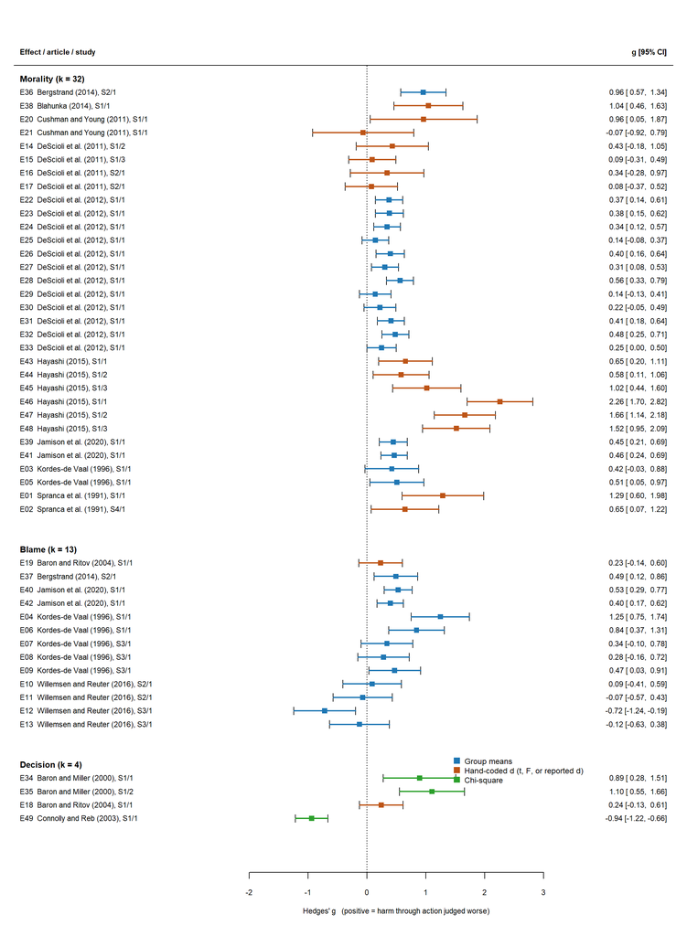

```r
ord <- order(factor(es$dv_group, levels = c("Morality", "Blame", "Decision")),
             es$article, es$effect_id)
f <- es[ord, ]
grp <- factor(f$dv_group, levels = c("Morality", "Blame", "Decision"))

## Leave two blank rows above each DV group for its label
k <- nrow(f); ng <- table(grp)
rows  <- integer(k); pos <- k + 3 * length(ng); heads <- integer(0)
for (lv in levels(grp)) {
  heads <- c(heads, pos); pos <- pos - 1
  idx <- which(grp == lv)
  rows[idx] <- pos:(pos - length(idx) + 1); pos <- pos - length(idx) - 2
}
cols <- c("group means" = "#1f77b4", "t statistic" = "#bd5416",
          "F statistic" = "#bd5416", "chi-square" = "#2ca02c")

metafor::forest(f$yi, f$vi, slab = paste0(f$effect_id, "  ", f$article, ", S", f$study, "/", f$sample),
       rows = rows, ylim = c(-1, max(heads) + 3), xlim = c(-6, 5.2), alim = c(-2, 3),
       at = -2:3, header = c("Effect / article / study", "g [95% CI]"),
       xlab = "Hedges' g   (positive = harm through action judged worse)", cex = .72)
## Redraw each interval and point in the color of its route
lo <- f$yi - 1.96 * sqrt(f$vi); hi <- f$yi + 1.96 * sqrt(f$vi)
segments(pmax(lo, -2), rows, pmin(hi, 3), rows, col = cols[f$es_input], lwd = 2)
points(f$yi, rows, pch = 15, cex = 1.1, col = cols[f$es_input])
text(-6, heads, paste0(levels(grp), " (k = ", ng, ")"), pos = 4, font = 2, cex = .8)
legend(x = 1.4, y = heads[3] + 1, bty = "n", cex = .75, pch = 15, pt.cex = 1.3,
       col = cols[c(1, 2, 4)], legend = c("Group means", "Hand-coded d (t, F, or reported d)", "Chi-square"))
```

Almost every point sits to the right of zero, and the spread is far wider than the confidence intervals. That spread is the heterogeneity the models in Sections 2–3 quantify. Four features stand out. Hayashi (2015) supplies the three largest effects (*g* = 1.5 to 2.3), all from paired *t* tests with Japanese second-graders, sixth-graders, and adults. The 12 DeScioli et al. (2012) rows are small and very precise, because the M/SD route was used and *N* ≈ 150. Three of the four Willemsen and Reuter (2016) blame rows are negative, as they argued in a paper titled “Is there really an omission effect?” And Connolly and Reb (2003), at the bottom, is the only large effect in the opposite direction: people chose to vaccinate.

### 1.6 How much does the effect-size route matter?

A sensitivity check the paper does not run: re-pool the 49 effects using the coding sheet’s “best estimate” for every row, or using paired-data *d*<sub>z</sub> = *t*/√*N* for every within-subject row that reports a *t*.

```r
fit3 <- function(dat) rma.mv(yi, vi, random = ~ 1 | article / unit, data = dat)

alt_best <- es
alt_best$yi <- es$best_estimate          # already signed: Connolly and Reb is entered as -0.94
alt_best$vi <- with(es, 4 / n + best_estimate^2 / (2 * n))

alt_dz <- es
w <- with(es, design_type == "Within-subject" & !is.na(t) & es_input != "chi-square")
alt_dz$yi[w] <- with(es[w, ], t / sqrt(n))
alt_dz$vi[w] <- with(es[w, ], 1 / n + (t / sqrt(n))^2 / (2 * n))

sens <- lapply(list("Authors' routes (as published)" = es,
                    "Sheet's best estimate for every row" = alt_best,
                    "Paired d_z for within-subject rows with t" = alt_dz), fit3)
kable(data.frame(Choice = names(sens),
                 g = sapply(sens, function(m) m$b[1]),
                 lower = sapply(sens, function(m) m$ci.lb), upper = sapply(sens, function(m) m$ci.ub)),
      digits = 2, row.names = FALSE)
```

| Choice | g | lower | upper |
| --- | --- | --- | --- |
| Authors’ routes (as published) | 0.45 | 0.14 | 0.77 |
| Sheet’s best estimate for every row | 0.57 | 0.20 | 0.95 |
| Paired d_z for within-subject rows with t | 0.47 | 0.16 | 0.77 |

Using paired *d*<sub>z</sub> barely moves the estimate (0.45 to 0.47). Using the sheet’s own “best estimate” for every row raises it to 0.57, mostly because the DeScioli et al. (2012) rows triple in size. The conclusion (a positive effect whose interval excludes zero) holds under all three, but how large the effect is depends partly on a coding decision that the paper never mentions.

## 2. Dependent effect sizes: 49 effects, 25 units, 13 articles

Decide what counts as one observation. Several of the 49 effects share participants: DeScioli et al. (2012) contributes 12 ratings from one sample, and four samples were measured on two DVs. Treating them as 49 independent studies would overstate the precision of the pooled mean.

The authors handle this two ways, and the paper reports both:

- **Collapse, then pool (two-level model).** Average the effects within each sample-by-DV unit with `MAd::agg()`, assuming the effects within a unit correlate at *r* = .5 (the Borenstein et al., 2009, “BHHR” method). That leaves 25 independent units for an ordinary random-effects model. This was the preregistered analysis.
- **Model the nesting (three-level model).** Keep all 49 effects and give the model a random effect for each unit *and* each article: `rma.mv(random = ~ 1 | article / unit)`. This was added after open peer review and is the headline result.

```r
collapse_units <- function(dat) {
  a <- agg(id = unit, es = yi, var = vi, cor = .5, method = "BHHR", mod = NULL, data = dat)
  names(a)[names(a) == "id"] <- "unit"
  n <- aggregate(n ~ unit, data = dat, FUN = max)
  merge(a, n, by = "unit")
}
fit2 <- function(dat) {
  u <- collapse_units(dat)
  rma(es, var, method = "REML", data = u, slab = unit)
}

units <- collapse_units(es)
nrow(units)
```

```
#> [1] 25
```

```r
head(units[order(-units$es), ], 8)
```

|  | unit | es | var | n |
| --- | --- | --- | --- | --- |
| 14 | Hayashi (2015) / S1 / Sample 1 - DV1 | 1.457 | 0.051 | 80 |
| 22 | Spranca et al. (1991) / S1 / Sample 1 - DV1 | 1.289 | 0.125 | 38 |
| 16 | Hayashi (2015) / S1 / Sample 3 - DV1 | 1.269 | 0.065 | 60 |
| 15 | Hayashi (2015) / S1 / Sample 2 - DV1 | 1.123 | 0.048 | 76 |
| 2 | Baron and Miller (2000) / S1 / Sample 2 - DV1 | 1.104 | 0.079 | 70 |
| 20 | Kordes-de Vaal (1996) / S1 / Sample 1 - DV2 | 1.045 | 0.045 | 74 |
| 7 | Blahunka (2014) / S1 / Sample 1 - DV1 | 1.043 | 0.090 | 50 |
| 5 | Bergstrand (2014) / S2 / Sample 1 - DV1 | 0.958 | 0.038 | 115 |

## 3. The overall omission-bias effect

Estimate the average omission-commission difference across all studies, and how much the true effect varies from study to study.

```r
m2 <- fit2(es)
m2
```

```
#>
#> Random-Effects Model (k = 25; tau^2 estimator: REML)
#>
#> tau^2 (estimated amount of total heterogeneity): 0.2674 (SE = 0.0920)
#> tau (square root of estimated tau^2 value):      0.5171
#> I^2 (total heterogeneity / total variability):   88.66%
#> H^2 (total variability / sampling variability):  8.82
#>
#> Test for Heterogeneity:
#> Q(df = 24) = 194.1777, p-val < .0001
#>
#> Model Results:
#>
#> estimate      se    zval    pval   ci.lb   ci.ub
#>   0.5271  0.1132  4.6582  <.0001  0.3053  0.7489  ***
#>
#> ---
#> Signif. codes:  0 '***' 0.001 '**' 0.01 '*' 0.05 '.' 0.1 ' ' 1
```

```r
m3 <- fit3(es)
m3
```

```
#>
#> Multivariate Meta-Analysis Model (k = 49; method: REML)
#>
#> Variance Components:
#>
#>             estim    sqrt  nlvls  fixed        factor
#> sigma^2.1  0.2926  0.5409     13     no       article
#> sigma^2.2  0.0219  0.1480     25     no  article/unit
#>
#> Test for Heterogeneity:
#> Q(df = 48) = 271.2183, p-val < .0001
#>
#> Model Results:
#>
#> estimate      se    zval    pval   ci.lb   ci.ub
#>   0.4523  0.1602  2.8226  0.0048  0.1382  0.7664  **
#>
#> ---
#> Signif. codes:  0 '***' 0.001 '**' 0.01 '*' 0.05 '.' 0.1 ' ' 1
```

```r
icc  <- m3$sigma2[1] / sum(m3$sigma2)
W    <- diag(1 / es$vi); X <- model.matrix(m3)
P    <- W - W %*% X %*% solve(t(X) %*% W %*% X) %*% t(X) %*% W
I2ml <- 100 * sum(m3$sigma2) / (sum(m3$sigma2) + (m3$k - m3$p) / sum(diag(P)))
c(ICC_article = icc, I2_multilevel = I2ml)
```

```
#>   ICC_article I2_multilevel
#>          0.93         91.36
```

Main effect (p. 1505): 21 samples, 49 effect sizes, 13 articles, *g* = 0.45, 95% CI [0.14, 0.77], “with very high heterogeneity.” Heterogeneity (pp. 1505–1506): Q(48) = 271.22, *p* < .001, *I*² = 93.68%. The two-level results were moved to the Supplement and described as “very similar.”

The three-level model gives **g = 0.45, 95% CI [0.14, 0.77]**, matching the paper. The two-level model on the 25 collapsed units gives **g = 0.53, 95% CI [0.31, 0.75]**: a larger mean and a much narrower interval.

Why the gap? The three-level model finds that almost all of the true-effect variance sits *between articles* (article-level share = 0.93), not between samples within an article. In effect there are 13 independent pieces of evidence, not 25, so the interval widens. And because the model now weights by article, Hayashi (2015), whose six large effects came from three samples, carries less weight than before, so the mean falls. “Very similar” undersells the difference in precision: the lower bound drops from 0.31 to 0.14.

Q and its df match the paper exactly. Our multilevel *I*² is 91.4%, not 93.68%; we could not find the formula that yields the published value. Either way, most of the variation in observed effects is real variation in the effect, not sampling error.

A forest plot of the 25 collapsed units, as in the authors’ file:

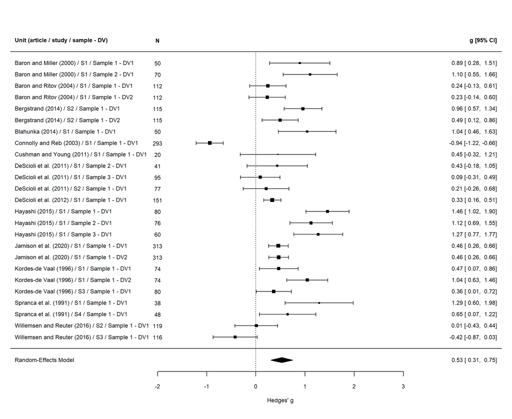

```r
metafor::forest(m2, xlim = c(-5, 5), alim = c(-2, 3), at = -2:3, ilab = units$n, ilab.xpos = -2,
       header = c("Unit (article / study / sample - DV)", "g [95% CI]"),
       xlab = "Hedges' g", cex = .75)
text(-2, m2$k + 2, "N", font = 2, cex = .75)
```

## 4. Effects by DV type, and without Connolly and Reb

Test H1a and H1b separately. H1a says harm through action is judged less moral and more blameworthy. H1b says people *choose* inaction over action. Judgments about others and one’s own decisions need not move together.

```r
dv_fits <- lapply(c(Morality = "Morality", Blame = "Blame", Decision = "Decision"),
                  function(lv) fit2(es[es$dv_group == lv, ]))
dv_tab <- data.frame(DV = names(dv_fits),
                     k = sapply(dv_fits, `[[`, "k"),
                     g = sapply(dv_fits, function(m) m$b[1]),
                     lower = sapply(dv_fits, `[[`, "ci.lb"), upper = sapply(dv_fits, `[[`, "ci.ub"),
                     Q = sapply(dv_fits, `[[`, "QE"), I2 = sapply(dv_fits, `[[`, "I2"))
kable(dv_tab, digits = 2, row.names = FALSE)
```

| DV | k | g | lower | upper | Q | I2 |
| --- | --- | --- | --- | --- | --- | --- |
| Morality | 14 | 0.71 | 0.47 | 0.95 | 56.6 | 79.7 |
| Blame | 7 | 0.32 | 0.01 | 0.64 | 26.5 | 82.3 |
| Decision | 4 | 0.30 | -0.62 | 1.21 | 66.4 | 94.7 |

Table 2 and p. 1505: morality (*k* = 14) *g* = 0.71, 95% CI [0.47, 0.94]; blame (*k* = 7) *g* = 0.32, [0.01, 0.64]; decision (*k* = 4) *g* = 0.30, [−0.62, 1.21], “suggesting weak to no support for omission bias” in decisions. Table 5: H1a supported for morality and blame; H1b not supported.

These are two-level models on collapsed units, so *k* counts units, not effects. The morality effect is about twice the blame effect. The decision interval is enormous because it rests on four units, one of which (Connolly and Reb) points the other way.

The DV difference is not statistically significant, though. The moderator test in the three-level model:

```r
rma.mv(yi, vi, mods = ~ dv_group, random = ~ 1 | article / unit, data = es)
```

```
#>
#> Multivariate Meta-Analysis Model (k = 49; method: REML)
#>
#> Variance Components:
#>
#>             estim    sqrt  nlvls  fixed        factor
#> sigma^2.1  0.2447  0.4947     13     no       article
#> sigma^2.2  0.0372  0.1930     25     no  article/unit
#>
#> Test for Residual Heterogeneity:
#> QE(df = 46) = 236.1745, p-val < .0001
#>
#> Test of Moderators (coefficients 2:3):
#> QM(df = 2) = 1.4740, p-val = 0.4786
#>
#> Model Results:
#>
#>                   estimate      se     zval    pval    ci.lb   ci.ub
#> intrcpt             0.4149  0.1903   2.1803  0.0292   0.0419  0.7879  *
#> dv_groupDecision   -0.1951  0.2867  -0.6803  0.4963  -0.7571  0.3669
#> dv_groupMorality    0.1413  0.1683   0.8396  0.4011  -0.1885  0.4711
#>
#> ---
#> Signif. codes:  0 '***' 0.001 '**' 0.01 '*' 0.05 '.' 0.1 ' ' 1
```

### Dropping the outlier

The paper’s second analysis removes Connolly and Reb (2003), which the influence diagnostics flag. The authors’ file does this by re-running every chunk on a separate spreadsheet version. Here it is a filter.

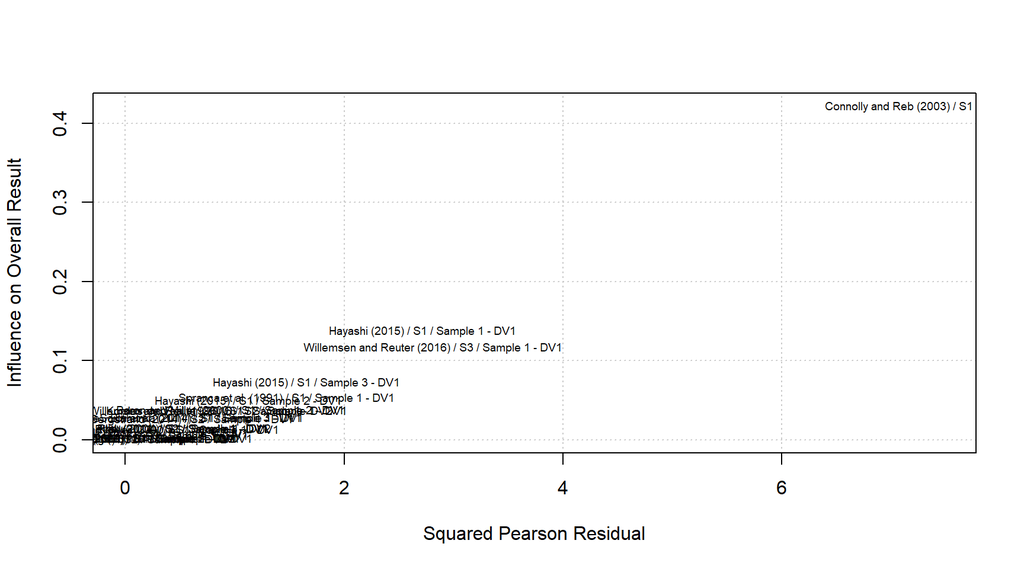

```r
baujat(m2, symbol = "slab", cex = .6)
```

```r
es_nc <- es[es$article != "Connolly and Reb (2003)", ]
m3_nc <- fit3(es_nc)
m3_nc
```

```
#>
#> Multivariate Meta-Analysis Model (k = 48; method: REML)
#>
#> Variance Components:
#>
#>             estim    sqrt  nlvls  fixed        factor
#> sigma^2.1  0.1412  0.3757     12     no       article
#> sigma^2.2  0.0196  0.1399     24     no  article/unit
#>
#> Test for Heterogeneity:
#> Q(df = 47) = 180.0374, p-val < .0001
#>
#> Model Results:
#>
#> estimate      se    zval    pval   ci.lb   ci.ub
#>   0.5599  0.1221  4.5861  <.0001  0.3206  0.7991  ***
#>
#> ---
#> Signif. codes:  0 '***' 0.001 '**' 0.01 '*' 0.05 '.' 0.1 ' ' 1
```

```r
dec_nc <- fit2(es_nc[es_nc$dv_group == "Decision", ])
c(decision_g = dec_nc$b[1], lower = dec_nc$ci.lb, upper = dec_nc$ci.ub)
```

```
#> decision_g      lower      upper
#>      0.709      0.163      1.254
```

Excluding Connolly and Reb (p. 1505): overall *g* = 0.56, 95% CI [0.32, 0.80]; decision *g* = 0.71, [0.16, 1.25]; Q(47) = 180.04, *I*² = 84.24%. The authors label this an “unregistered exploratory analysis.”

Reproduced: g = 0.56, 95% CI [0.32, 0.80]. One article moves the overall estimate by a tenth of a standard deviation and turns the decision result from null to clearly positive. That is the fragility of a 13-article literature, and the reason this analysis should be read as exploratory. Connolly and Reb is not a coding error; it is a vaccination decision in which acting was the norm.

## 5. Publication bias

Ask whether the studies we can see are a biased sample of those that were run. If small studies with null results went unpublished, the funnel plot will be lopsided and the pooled mean too high. Every method below makes a different assumption about *how* studies go missing, so the authors report many and look for agreement.

All of the tests in this section, in the authors’ code and here, are run on the **two-level model of 25 collapsed units** (`g` = 0.53), not on the three-level model. The note to the paper’s Table 3 says “analyses conducted on multivariate three-level model.” The numbers in Tables 3 and 4 match the two-level input.

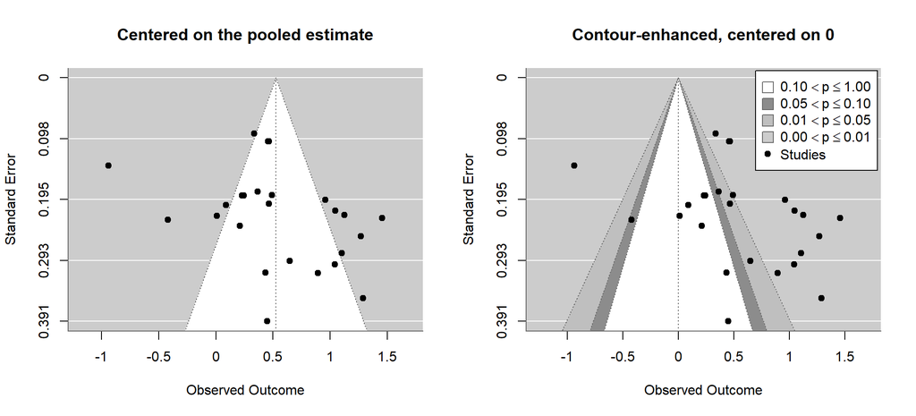

```r
par(mfrow = c(1, 2))
metafor::funnel(m2); title("Centered on the pooled estimate")
metafor::funnel(m2, level = c(90, 95, 99), shade = c("white", "gray55", "gray75"),
       refline = 0, legend = TRUE); title("Contour-enhanced, centered on 0")
```

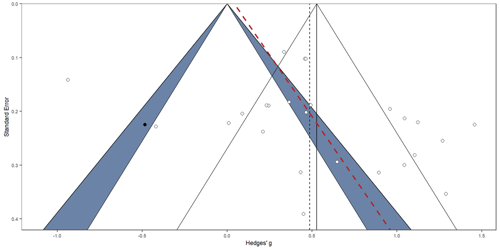

```r
viz_funnel(m2, y_axis = "se", contours = TRUE, trim_and_fill = TRUE,
           trim_and_fill_side = "left", sig_contours = TRUE, egger = TRUE,
           detail_level = 5, xlab = "Hedges' g")
```

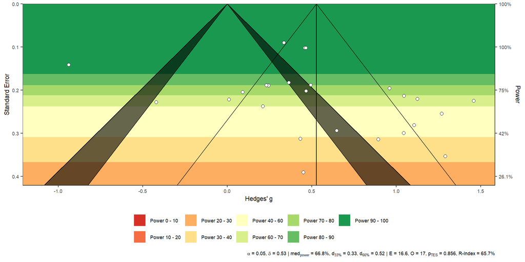

```r
viz_sunset(m2, xlab = "Hedges' g", contours = TRUE)
```

The contour plot shades regions where a study would be significant at *p* < .10, .05, and .01. Bias from selective publication shows up as a cluster of studies just inside the shaded regions and a gap in the white region near zero. The sunset plot colors each study by its power to detect the pooled effect.

```r
units$sei <- sqrt(units$var)

taf  <- metafor::trimfill(m2)
rank <- ranktest(m2)
egg  <- regtest(m2)
fsn_ <- fsn(es, var, data = units, type = "Rosenthal")
pet   <- lm(es ~ sei, weights = 1 / var, data = units)
peese <- lm(es ~ var, weights = 1 / var, data = units)
pu   <- puniform(yi = units$es, vi = units$var, side = "right", method = "P", plot = FALSE)
sel  <- weightfunct(units$es, units$var, steps = c(.025, 1))
hc_  <- hc(m2)
sel_est <- sel[[2]]$par[2]; sel_se <- sqrt(diag(solve(sel[[2]]$hessian)))[2]
```

```r
pc <- dmetar::pcurve(meta::metagen(units$es, units$sei, studlab = units$unit),
                     effect.estimation = TRUE, N = units$n, dmin = -3, dmax = 3)
```

```r
bias <- rbind(
  c("Unadjusted two-level model",          fmt(m2$b),          sprintf("[%s, %s]", fmt(m2$ci.lb), fmt(m2$ci.ub)), "0.53"),
  c("Trim and fill (1 study imputed)",     fmt(taf$b),         sprintf("[%s, %s]", fmt(taf$ci.lb), fmt(taf$ci.ub)), "0.49 [0.26, 0.72]"),
  c("Three-parameter selection model",     fmt(sel_est),       sprintf("[%s, %s]", fmt(sel_est - 1.96 * sel_se), fmt(sel_est + 1.96 * sel_se)), "0.34 [-0.03, 0.72]"),
  c("Henmi and Copas",                     fmt(hc_$beta),      sprintf("[%s, %s]", fmt(hc_$ci.lb), fmt(hc_$ci.ub)), "0.41 [0.12, 0.70]"),
  c("p-uniform",                           fmt(pu$est),        sprintf("[%s, %s]", fmt(pu$ci.lb), fmt(pu$ci.ub)), "0.74 [0.48, 1.00]"),
  c("PET (intercept)",                     fmt(coef(pet)[1]),  sprintf("[%s, %s]", fmt(confint(pet)[1, 1]), fmt(confint(pet)[1, 2])), "0.04 [-0.49, 0.57]"),
  c("PEESE (intercept)",                   fmt(coef(peese)[1]),sprintf("[%s, %s]", fmt(confint(peese)[1, 1]), fmt(confint(peese)[1, 2])), "0.21 [-0.11, 0.53]"),
  c("p-curve estimate (d)",                fmt(pc$dEstimate),  "", "0.70"),
  c("Rank correlation (Kendall's tau)",    fmt(rank$tau),      sprintf("p = %s", fmt(rank$pval, 3)), "0.20, p = .170"),
  c("Egger regression (z)",                fmt(egg$zval),      sprintf("p = %s", fmt(egg$pval, 3)), "1.97, p = .048"),
  c("Fail-safe N (Rosenthal)",             fsn_$fsnum,         "", "not reported"))
kable(bias, col.names = c("Method", "Estimate", "95% CI / p", "Paper (Tables 3-4)"))
```

| Method | Estimate | 95% CI / p | Paper (Tables 3-4) |
| --- | --- | --- | --- |
| Unadjusted two-level model | 0.53 | [0.31, 0.75] | 0.53 |
| Trim and fill (1 study imputed) | 0.49 | [0.26, 0.72] | 0.49 [0.26, 0.72] |
| Three-parameter selection model | 0.34 | [-0.03, 0.72] | 0.34 [-0.03, 0.72] |
| Henmi and Copas | 0.41 | [0.12, 0.70] | 0.41 [0.12, 0.70] |
| p-uniform | 0.74 | [0.48, 1.00] | 0.74 [0.48, 1.00] |
| PET (intercept) | 0.04 | [-0.49, 0.57] | 0.04 [-0.49, 0.57] |
| PEESE (intercept) | 0.21 | [-0.11, 0.53] | 0.21 [-0.11, 0.53] |
| p-curve estimate (d) | 0.70 |  | 0.70 |
| Rank correlation (Kendall’s tau) | 0.20 | p = 0.170 | 0.20, p = .170 |
| Egger regression (z) | 1.97 | p = 0.048 | 1.97, p = .048 |
| Fail-safe N (Rosenthal) | 1308 |  | not reported |

p. 1506: p-uniform, p-curve, and Henmi and Copas “showed effects meaningfully different from the null,” but the three-parameter selection model gave *g* = 0.34, [−0.03, 0.72], “with weak to no omission bias effects using PET and PEESE.” Several asymmetry tests had *p* values near .05, “indicative of possible publication bias.”

Every number reproduces. Read them as a range, not a verdict. Methods that assume only significant results get published and correct for it (p-uniform, p-curve) *raise* the estimate here, which happens when heterogeneity is high (*I*² near 90%) and should not be trusted. Methods that model the relation between effect size and precision (PET, PEESE, the selection model) pull the estimate toward zero. Egger’s test finds that less precise units report larger effects (*p* = 0.048). The fail-safe *N* of 1308 looks reassuring but assumes the missing studies average exactly zero, and is no longer recommended.

The honest summary is the paper’s: an effect that survives most corrections, with real signs of small-study bias, in a literature too small for any single method to settle it.

## 6. Moderators

Explain the heterogeneity. If the omission bias is stronger in some kinds of studies, the average of 0.45 hides that structure. Six moderators were tested:

- **Familiarity** with the target (H2a stronger for familiar targets, H2b for unfamiliar)
- **Role responsibility** for the target, such as a parent or doctor (H3a stronger with responsibility, H3b without)
- **Outcome**: whether harm actually occurred (H4 effect even without a negative outcome; H5 stronger with one)
- **Design**: within- vs. between-subject (H6a stronger within, H6b no difference)
- **Target**: self vs. others (exploratory)
- **Publication status** (a bias check; only one unpublished study)

The authors use three tools, and each answers a slightly different question:

1. **Subgroup analysis.** Fit a two-level model to each category separately, then test whether the two estimates differ (a Wald test, written in the original as a fixed-effect meta-regression on the two estimates).
2. **Three-level meta-regression.** Add the moderator as a predictor in the three-level model on all effects. This respects the nesting, but with 13 articles it has little power.
3. **MetaForest.** A random-forest method that ranks moderators by how much they improve out-of-sample prediction. The authors added it after review “to address the issue of limited statistical power.”

### 6.1 Subgroup analyses

```r
subgroup <- function(var, levels, data = es) {
  fits <- lapply(levels, function(lv) fit2(data[!is.na(data[[var]]) & data[[var]] == lv, ]))
  est  <- sapply(fits, function(m) m$b[1]); se <- sapply(fits, `[[`, "se")
  z    <- (est[2] - est[1]) / sqrt(se[1]^2 + se[2]^2)
  data.frame(moderator = var, level = levels, k = sapply(fits, `[[`, "k"),
             g = est, lower = sapply(fits, `[[`, "ci.lb"), upper = sapply(fits, `[[`, "ci.ub"),
             p_difference = c(2 * pnorm(-abs(z)), NA))
}

sub_tab <- rbind(
  subgroup("familiarity",    c("familiar with target", "not familiar with target")),
  subgroup("responsibility", c("responsibility over target", "unclear responsibility over target")),
  subgroup("outcome",        c("negative outcome", "no clear negative outcome")),
  subgroup("design_type",    c("Between-subject", "Within-subject")),
  subgroup("self_other",     c("self", "other")),
  subgroup("published",      c("Yes", "No")))
kable(sub_tab, digits = 3, row.names = FALSE)
```

| moderator | level | k | g | lower | upper | p_difference |
| --- | --- | --- | --- | --- | --- | --- |
| familiarity | familiar with target | 12 | 0.576 | 0.239 | 0.914 | 0.106 |
| familiarity | not familiar with target | 6 | 0.276 | 0.139 | 0.412 | NA |
| responsibility | responsibility over target | 7 | -0.051 | -0.419 | 0.317 | 0.001 |
| responsibility | unclear responsibility over target | 17 | 0.601 | 0.441 | 0.761 | NA |
| outcome | negative outcome | 13 | 0.713 | 0.418 | 1.008 | 0.048 |
| outcome | no clear negative outcome | 13 | 0.301 | 0.021 | 0.582 | NA |
| design_type | Between-subject | 9 | 0.434 | 0.166 | 0.702 | 0.452 |
| design_type | Within-subject | 16 | 0.593 | 0.277 | 0.909 | NA |
| self_other | self | 4 | 1.416 | 0.596 | 2.235 | 0.026 |
| self_other | other | 25 | 0.456 | 0.259 | 0.653 | NA |
| published | Yes | 24 | 0.508 | 0.281 | 0.735 | 0.095 |
| published | No | 1 | 1.043 | 0.456 | 1.630 | NA |

pp. 1506–1507: familiar 12 studies, *g* = 0.58 [0.24, 0.91] vs. not familiar 6, *g* = 0.28 [0.14, 0.41]; clear responsibility 7, *g* = −0.05 [−0.42, 0.32] vs. no clear responsibility 17, *g* = 0.60 [0.44, 0.76]; self 4, *g* = 1.42 [0.60, 2.24] vs. others 25, *g* = 0.46 [0.26, 0.65]; negative outcome 13, *g* = 0.71 [0.42, 1.01] vs. no clear negative outcome 13, *g* = 0.30 [0.02, 0.58]; between 9, *g* = 0.43 [0.17, 0.70] vs. within 16, *g* = 0.59 [0.28, 0.91].

All subgroup estimates reproduce. Three contrasts reach *p* < .05: responsibility (the bias disappears when the decision maker has a clear role responsibility, as a parent or a doctor does), self vs. other (much larger when people decide about harm to themselves), and outcome (larger when harm actually occurs). Familiarity and design do not. Keep the counts in view: the “self” estimate rests on four units from two articles, and the published/unpublished contrast has one unpublished unit, so it tests nothing.

These subgroup models also ignore that units from the same article are correlated, and each category is fit with its own heterogeneity. The next section addresses the first problem.

### 6.2 Three-level meta-regressions, and a bug in the original

**In the authors’ file, five of the six three-level moderator models are run on the wrong data.** Each moderator section begins with `rma.mv(yi, vi, mods = ~ Moderator, random = ~ 1 | Article.Name/articlestudy, data = dataset1)`. But `dataset1` is not the full data at that point. It still holds whatever subgroup the *previous* section created last. The study-design model is run on the 13 blame effects only, the responsibility model on within-subject effects only, and so on. Only the DV-type model sees all 49 effects. The Supplement reports these as the three-level moderator results, and the paper’s Table 5 cites them (“not supported in three-level”).

The table re-runs each model two ways: on the subset the original code actually used, and on all 49 effects.

```r
## "undetermined" familiarity and responsibility codes were set to NA before these models
## in the original; blank cells in the tidy data are already NA.
ml_fit <- function(var, data) {
  d <- data[!is.na(data[[var]]) & data[[var]] != "", ]
  rma.mv(yi, vi, mods = as.formula(paste("~", var)), random = ~ 1 | article / unit, data = d)
}

## The data frame `dataset1` held at each point in the original file
as_run <- list(
  design_type    = es[es$dv_group == "Blame", ],
  responsibility = es[es$design_type == "Within-subject", ],
  familiarity    = es[es$responsibility %in% "unclear responsibility over target", ],
  outcome        = es[es$familiarity %in% "not familiar with target", ],
  self_other     = es[es$outcome == "no clear negative outcome", ],
  published      = es[es$self_other == "other", ])
subset_label <- c(design_type = "Blame DV only", responsibility = "Within-subject only",
                  familiarity = "Unclear responsibility only", outcome = "Not familiar only",
                  self_other = "No negative outcome only", published = "Other-target only")

ml_tab <- do.call(rbind, lapply(names(as_run), function(v) {
  a <- ml_fit(v, as_run[[v]]); b <- ml_fit(v, es)
  data.frame(moderator = v,
             original_data = subset_label[[v]], k_original = a$k,
             b_original = a$b[2], p_original = a$QMp,
             k_corrected = b$k, b_corrected = b$b[2], p_corrected = b$QMp)
}))
kable(ml_tab, digits = 3, row.names = FALSE)
```

| moderator | original_data | k_original | b_original | p_original | k_corrected | b_corrected | p_corrected |
| --- | --- | --- | --- | --- | --- | --- | --- |
| design_type | Blame DV only | 13 | -0.114 | 0.830 | 49 | 0.086 | 0.811 |
| responsibility | Within-subject only | 17 | 0.215 | 0.065 | 28 | 0.293 | 0.003 |
| familiarity | Unclear responsibility only | 15 | -0.511 | 0.082 | 28 | -0.068 | 0.477 |
| outcome | Not familiar only | 11 | 0.025 | 0.878 | 49 | 0.073 | 0.735 |
| self_other | No negative outcome only | 28 | 0.005 | 0.951 | 49 | 0.145 | 0.057 |
| published | Other-target only | 43 | -0.674 | 0.268 | 49 | -0.631 | 0.338 |

The `k_original` column matches the *k* printed in the authors’ output (13, 17, 15, 11, 28, 43), which confirms the diagnosis. Fit to all effects, two conclusions change:

- **Responsibility** goes from marginal (*p* = 0.065, within-subject studies only) to clearly significant (*b* = 0.29, *p* = 0.003), agreeing with the subgroup result and MetaForest.
- **Self vs. other** goes from essentially zero (*b* = 0.005), because the original model saw only studies with no negative outcome, to *b* = 0.15 (*p* = 0.057), in the same direction as the subgroup result.

Outcome, design, and familiarity stay null in the three-level model with or without the fix. With 13 articles these models have little power, so a non-significant *p* is not evidence of no moderation.

This is a copy-and-paste bug, not a judgment call, and it is invisible when you read any single chunk. It is the strongest argument for the function-based structure used here: a model that takes `data` as an argument cannot silently inherit the last subset.

### 6.3 MetaForest

```r
mf_dat <- data.frame(yi = es$yi, vi = es$vi,
  Familiarity.with.target    = factor(ifelse(is.na(es$familiarity), "undetermined", es$familiarity)),
  Responsibility.over.target = factor(ifelse(is.na(es$responsibility), "undetermined", es$responsibility)),
  Outcome.valence = factor(es$outcome), Design.type = factor(es$design_type),
  Self.other = factor(es$self_other))

set.seed(42)
mf <- MetaForest(yi ~ Familiarity.with.target + Responsibility.over.target + Outcome.valence +
                   Design.type + Self.other,
                 data = mf_dat, whichweights = "random", num.trees = 500, method = "REML")
c(R2_oob = mf$forest$r.squared)
```

```
#> R2_oob
#>  0.373
```

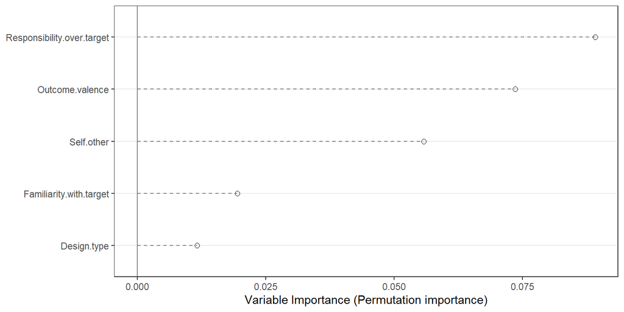

```r
VarImpPlot(mf)
```

p. 1507 and Figure 4: R² (OOB) = .29; all five moderators had positive variable importance, ranked responsibility, outcome, self vs. other, familiarity, design. Table 5 concludes “likely moderation” for outcome and design based on MetaForest.

Variable importance measures how much worse the forest predicts when a moderator’s values are scrambled. Positive means the moderator helps predict effect sizes out of sample. The ranking here matches the paper’s exactly. Our R² (OOB) of 0.37 differs from .29, which is common for random forests: results depend on the seed *and* on the package version that consumes it. The authors used the same seed with 2020 versions of `metaforest` and `ranger`.

Two cautions. MetaForest ignores the nesting of effects within articles. And with 49 effects, positive importance is a weak standard: it can say a moderator is worth studying, not that its effect is established. Using MetaForest to upgrade null meta-regressions to “likely moderation” leans on it harder than it can bear.

## 7. Summary

| Hypothesis | Paper’s conclusion (Table 5) | This replication |
| --- | --- | --- |
| H1a morality: action judged less moral | Supported, *g* = 0.71 | Reproduced |
| H1a blame: action judged more blameworthy | Supported, *g* = 0.32 | Reproduced |
| H1b decisions: inaction preferred | Not supported, *g* = 0.30 | Reproduced; becomes *g* = 0.71 without Connolly and Reb |
| H2 familiarity | No evidence for H2b, weak for H2a | Null in subgroups (*p* = .11) and in the corrected three-level model |
| H3b stronger without role responsibility | Supported | Reproduced in subgroups (*p* = .001); corrected three-level *p* = .003 (original, wrong subset: .065) |
| Self vs. other (exploratory) | Support for moderation | Subgroup *p* = .03 (4 units); corrected three-level *p* = .06 (original, wrong subset: .95) |
| H4 effect even without negative outcome | Supported | Reproduced, *g* = 0.30 [0.02, 0.58] |
| H5 stronger with negative outcome | Mixed support, likely moderation | Subgroup *p* = .048; three-level null with or without the fix |
| H6 design | Mixed support | Null in subgroups and in the three-level model |

Every number in the published paper that comes from this code reproduces from the tidy data. The replication adds three things the paper does not show: the pooled estimate depends on how within-subject effects are standardized (Section 1.6); the publication-bias table uses the two-level model, not the three-level one its note names (Section 5); and the three-level moderator results in the Supplement were fit to the wrong subsets (Section 6.2).